# Lab 12

```r
library(readr)
library(ggplot2)
library(dplyr)
library(glmnet)
theme_set(theme_minimal())
```

This lab has two parts. The first has you re-do my description of the concentration of measure, varying the dimensionality to see how it effects the concentration. In the second, you’ll use the California housing dataset again, but now make use of the entire dataset.

## Concentration of measure

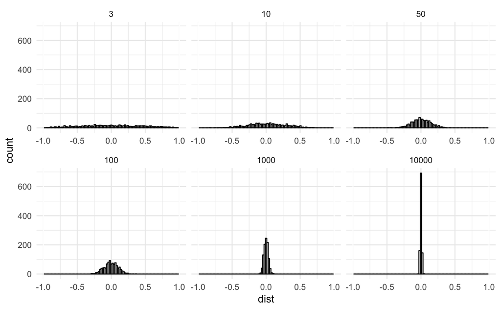

```r
n <- 1000
df <- NULL
for (d in c(3, 10, 50, 100, 1000, 10000))
{
  X <- matrix(runif(n * d, min = -1, max = 1), ncol = d)
  dist <- apply(X, 1, median)
  df <- bind_rows(df, tibble(d = d, dist = dist))
}
ggplot(df, aes(dist)) +
  geom_histogram(bins = 100, color = "black", fill = "white") +
  facet_wrap(~d, scale = "free_x") +
  geom_vline(xintercept = -1, color = "white") +
  geom_vline(xintercept = 1, color = "white")
```

## The mgcv package

We will need one new package today. You can install it with:

```r
if (!require(mgcv))
{
  install.packages("mgcv")
}
library(mgcv)
```

## Read in (entire) California housing data

Today I will have you again look at a dataset of California housing prices by census tract. This time, though, you are allowed to look at the entire dataset:

```r
housing <- read_csv("https://github.com/statsmaths/ml_data/blob/master/ca_house_price.csv?raw=true")
ocol <- ncol(housing)
```

I want you to fit the six models in the code below. In each block of code, fit the model on just the training set, make predictions on the original dataset, and use the `tapply` function to print out the RMSE for the training and validation sets. **I know this sounds counterintuitive, but I encourage you to overwrite the variables in each section (i.e., call all the models `model` and all of the predictions `pred`.** It will save you a lot of trouble over time.

1. Use a linear regression (feel free to use the `gam` function with no modifications) to predict the output variable as a function of latitude and longitude. Make sure that you only train on the training set.
2. Modify the above function with a univariate additive model using latitude and longitude:
3. Use an additive model with a two-dimensional smoothing term for the interaction of latitude and longitude:
4. Now, fit a penalized regression model on the dataset. Here you will need a model matrix; I’ve already gotten you started in the code chunk so you do not need to look up how to do that:

```r
X <- model.matrix( ~ -1 + ., data = housing[,seq(4, ocol)])
y <- housing$median_house_value

X_train <- X[housing$train_id == "train",]
y_train <- y[housing$train_id == "train"]
```

If you named your model `model`, the following code will show the most import variables for different values of lambda (modify the number 14 to change the number of variables that are included). We will use this information in the last model.

```r
B <- coef(model, s = model$lambda[14])
B[B[,1] != 0,,drop=FALSE]
```

```
5 x 1 sparse Matrix of class "dgCMatrix"
                                        1
(Intercept)                 189376.152457
mean_household_size_renters  -4112.127674
built_1939_or_earlier          332.894711
bedrooms_3                    -283.307791
mean_household_income            3.171777
```

5. Use k-Nearest neighbors with all of the variables. Try to use several values of k to find a value that performs reasonably well.

```r
library(FNN)
```

6. Use an additive model that has a smoothing term for latitude and longitude, but now include additional terms as suggested by the lasso regression. The details are up to you.

### Best model

Now, its time to build your final model. Using the information you’ve seen above, build a model that you think will be maximally predictive. You are free to be as creative as you would like short of using external datasets.

## Submitting your solutions

Finally, once you have your predictions saved as a variable called `pred`, run the following code to produce your your results:

```r
submit <- select(housing, obs_id, train_id)
submit <- mutate(submit, pred = pred)
write_csv(submit, "class12_submit.csv")
```

Now, upload the csv file to GitHub and you are done.